# Lab One Visualization and Data Preprocessing

2017-2018 California Department of Education Mathmematics Achievement

##### Create by An Nguyen, Andy Ho, Jodi Pafford, Tori Wheelis

January 25, 2019

## Business Understanding

This dataset contains information from schools within the California Department of Education. It specifically addresses school progress on standardized tests in Mathematics during the 2017-2018 school year. In part, the data will be used to support Local Education Agencies (LEA) in identifying strengths, weaknesses, and areas for improvement; assist in determining whether LEAs are eligible for assistance; and assist the SSPI in determining whether LEAs are eligible for more intensive state support/intervention. The school accountability system in California has 10 priorities. This dataset looks at one part of the 4th priority: Student Achievement. The dataset used in this analysis pertains specifically to the Mathematics curriculum and the progress made from 2017 school year to the 2018 school year.

From this dataset, we will look at how the state, each county, LEA, and campus increased or decreased their average distance above or below the passing standard score. This dataset also allows us to look at different programs (English Learner, Socioeconomic Disadvantaged, Students with Disabilities, Foster Youth, Homeless Youth) and race/ethnicities (Black/African American, American Indian or Alaska Native, Asian, Filipino, Hispanic, Pacific Islander, White, Multiple Races/Two or More). This project will address what differences in performance progress were seen between public and charter schools and its respective population subgroups, as described above. The outcome from this will provide further insights to California on the following:

- Is one subgroup out/underperforming another?
- How do districts compare performance wise? County Offices of Education? What about with subgroups?
- Charter v. Traditional schools? What about with subgroups?
- Any impacts/trends by # of kids tested?

Data is important because:

- It tells you how students performed on the California Assessment of Student Performance and Progress (CAASPP), california's state wide test.
- It tells you what achievement/performance gaps exist - so policy can be made to address these issues.

## Data Understanding

### Data Meaning

Codebook can be found at https://www.cde.ca.gov/ta/ac/cm/math18.asp

| Field # | Field Name | Description | Acceptable Values |
| --- | --- | --- | --- |
| 1 | cds | CDS Code | Text |
| 2 | rtype | Record Type | S=School Record D=District/LEA Record X=State Record |
| 3 | schoolname | School Name | Text |
| 4 | districtname | District Name | Text |
| 5 | countyname | County Name | Text |
| 6 | charter_flag | Charter School Flag | Y or blank |
| 7 | coe_flag | County Office of Education Flag | Y or blank |
| 8 | dass_flag | Dashboard Alternative School Status (DASS) School Flag | Y or blank |
| 9 | studentgroup | Student Group | ALL=All Students AA=Black/African American AI=American Indian or Alaska Native AS=Asian FI=Filipino HI=Hispanic PI=Pacific Islander WH=White MR=Multiple Races/Two or More EL=English Learner ELO=Englis… |
| 10 | currdenom | Current year number of valid students who took the Smarter Balanced summative assessment in Math For SWD student group only, students who have a current disability code in CALPADS or was a student wit… | Integer |
| 11 | currdenom_swd | Current year number of valid students with disabilities who took the Smarter Balanced summative assessment in Math and have a current disability code in CALPADS. These students and are included in the… | Integer |
| 12 | currstatus | Current Status - Average distance from Standard of students who took the Smarter Balanced summative assessment in Math (Rounded after calculations. For further information regarding this data field re… | Decimal |
| 13 | priordenom | Prior year number of valid students who took the Smarter Balanced summative assessment in Math | Integer |
| 14 | priordenom_swd | Prior year number of valid students with disabilities who took the Smarter Balanced summative assessment in Math and are included in the count to determine whether the SWD student group is assigned a … | Integer |
| 15 | priorstatus | Prior Status - Average distance from Standard of students who took the Smarter Balanced summative assessment in Math (Rounded after calculations. For further information regarding this data field refe… | Decimal |
| 16 | change | CHANGE - Difference between current status and prior status (Rounded after calculations. For further information regarding this data field refer to the CA School Dashboard Technical Guide.) | Decimal |
| 17 | statuslevel | Status Level (Determined after calculations and rounding. For further information regarding this data field refer to the CA School Dashboard Technical Guide.) | 1=Very Low 2=Low 3=Medium 4=High 5=Very High 0=No Data |
| 18 | changelevel | Change Level (Determined after calculations and rounding. For further information regarding this data field refer to the CA School Dashboard Technical Guide.) | 1=Decreased Significantly 2=Decreased 3=Maintained 4=Increased 5=Increased Significantly 0=No Data |
| 19 | color | Color | 1=Red 2=Orange 3=Yellow 4=Green 5=Blue 0=No Color |
| 20 | box | If a color was assigned, this value represents the specific 5x5 grid location | 10=Very High, Declined Significantly 20=Very High, Declined 30=Very High, Mantained 40=Very High, Increased 50=Very High, Increased Significantly 60=High, Declined Significantly 70=High, Declined 80=H… |
| 21 | hscutpoints | Indicates if the school or district is held to the High School cut points | Y or blank |
| 22 | curradjustment | The number of points removed from the current year status due to the participation rate being below 95% | Decimal |
| 23 | prioradjustment | The number of points removed from the prior year status due to the participation rate being below 95% | Decimal |
| 24 | pairshare_method | Pair and Share School Method. This identifies schools that do not serve grade 3 or higher and were assigned a district average, county average, or weighted school average of up to three receiving scho… | DA=District Average, CA=County Average, WA=Weighted Average, or Blank |
| 25 | caa_denom | Current year number of valid students who took the California Alternate Assessment in Math Only populated for records where studentgroup=ALL If the school or district did not test any students under t… | Integer |
| 26 | caa_level1_num | Current year number of valid students who took the California Alternate Assessment in Math and scored achievement level 1 Only populated for records where studentgroup=ALL and caa_denom>=11 | Integer |
| 27 | caa_level1_pct | Current year percent of valid students who took the California Alternate Assessment in Math and scored achievement level 1 Only populated for records where studentgroup=ALL and caa_denom>=11 | Decimal |
| 28 | caa_level2_num | Current year number of valid students who took the California Alternate Assessment in Math and scored achievement level 2 Only populated for records where studentgroup=ALL and caa_denom>=11 | Integer |
| 29 | caa_level2_pct | Current year percent of valid students who took the California Alternate Assessment in Math and scored achievement level 2 Only populated for records where studentgroup=ALL and caa_denom>=11 | Decimal |
| 30 | caa_level3_num | Current year percent of valid students who took the California Alternate Assessment in Math and scored achievement level 3 Only populated for records where studentgroup=ALL and caa_denom>=11 | Integer |
| 31 | caa_level3_pct | Current year percent of valid students who took the California Alternate Assessment in Math and scored achievement level 3 Only populated for records where studentgroup=ALL and caa_denom>=11 | Decimal |
| 32 | reportingyear | Reporting year | Text |

```python
import pandas as pd
import numpy as np
import matplotlib.pyplot as plt
import warnings
warnings.simplefilter('ignore', DeprecationWarning)
%matplotlib inline

#Import data from data file and name it math2018

excel_file = 'mathdownload2018.xlsx'
math2018=pd.read_excel(excel_file)
math_df=pd.read_excel(excel_file)
```

## Data Quality

Before we explore the data, one must be aware that the ‘All’ category total for any given campus/county/district data equals a number much smaller than if you were to add all the lines for similar campuses. This is because a student may be in several different categories (i.e., a student may be White (WH), in foster care (FOS), be living in a low socio-economic status (SED) and be served by special education (SWD) – student will ‘count’ in 4 of the 16 categories listed). No edits were needed for this phenomenon, however, we need to be aware of this as we move forward.

```python
#View basic info about the data file. There are many variables that have missing data.

math2018.info()
```

```
<class 'pandas.core.frame.DataFrame'>
RangeIndex: 148933 entries, 0 to 148932
Data columns (total 32 columns):
cds                 148933 non-null int64
rtype               148933 non-null object
schoolname          134824 non-null object
districtname        148916 non-null object
countyname          148916 non-null object
charter_flag        15685 non-null object
coe_flag            487 non-null object
dass_flag           7804 non-null object
studentgroup        148933 non-null object
currdenom           148933 non-null int64
currdenom_swd       10205 non-null float64
currstatus          97487 non-null float64
priordenom          148842 non-null float64
priordenom_swd      9952 non-null float64
priorstatus         96934 non-null float64
change              93435 non-null float64
statuslevel         148933 non-null int64
changelevel         148933 non-null int64
color               148933 non-null int64
box                 148933 non-null int64
hscutpoints         25661 non-null object
curradjustment      8577 non-null float64
prioradjustment     9795 non-null float64
pairshare_method    91 non-null object
caa_denom           10781 non-null float64
caa_level1_num      1411 non-null float64
caa_level1_pct      1411 non-null float64
caa_level2_num      1411 non-null float64
caa_level2_pct      1411 non-null float64
caa_level3_num      1411 non-null float64
caa_level3_pct      1411 non-null float64
ReportingYear       148933 non-null int64
dtypes: float64(15), int64(7), object(10)
memory usage: 36.4+ MB
```

```python
#View initial findings of the "ALL" cateogry equaly all the other categories from the same campus.

math2018[['cds', 'studentgroup', 'currdenom']]
```

|  | cds | studentgroup | currdenom |
| --- | --- | --- | --- |
| 0 | 0 | AA | 171493 |
| 1 | 0 | AI | 16622 |
| 2 | 0 | ALL | 3166312 |
| 3 | 0 | AS | 293068 |
| 4 | 0 | EL | 999885 |
| 5 | 0 | ELO | 512332 |
| 6 | 0 | EO | 1790552 |
| 7 | 0 | FI | 71096 |
| 8 | 0 | FOS | 20913 |
| 9 | 0 | HI | 1735972 |
| 10 | 0 | HOM | 115267 |
| 11 | 0 | MR | 118473 |
| 12 | 0 | PI | 14849 |
| 13 | 0 | RFP | 487553 |
| 14 | 0 | SED | 1978891 |
| 15 | 0 | SWD | 396607 |
| 16 | 0 | WH | 733191 |
| 17 | 1100170000000 | AA | 2 |
| 18 | 1100170000000 | ALL | 20 |
| 19 | 1100170000000 | AS | 1 |
| 20 | 1100170000000 | EL | 8 |
| 21 | 1100170000000 | ELO | 8 |
| 22 | 1100170000000 | EO | 8 |
| 23 | 1100170000000 | FI | 1 |
| 24 | 1100170000000 | FOS | 1 |
| 25 | 1100170000000 | HI | 14 |
| 26 | 1100170000000 | HOM | 2 |
| 27 | 1100170000000 | MR | 2 |
| 28 | 1100170000000 | SED | 16 |
| 29 | 1100170000000 | SWD | 5 |
| ... | ... | ... | ... |
| 148903 | 58727690000000 | EL | 6 |
| 148904 | 58727690000000 | ELO | 4 |
| 148905 | 58727690000000 | EO | 129 |
| 148906 | 58727690000000 | FI | 2 |
| 148907 | 58727690000000 | FOS | 1 |
| 148908 | 58727690000000 | HI | 42 |
| 148909 | 58727690000000 | HOM | 1 |
| 148910 | 58727690000000 | MR | 18 |
| 148911 | 58727690000000 | PI | 1 |
| 148912 | 58727690000000 | RFP | 2 |
| 148913 | 58727690000000 | SED | 67 |
| 148914 | 58727690000000 | SWD | 17 |
| 148915 | 58727690000000 | WH | 73 |
| 148916 | 58727695838305 | AA | 9 |
| 148917 | 58727695838305 | AI | 1 |
| 148918 | 58727695838305 | ALL | 152 |
| 148919 | 58727695838305 | AS | 4 |
| 148920 | 58727695838305 | EL | 6 |
| 148921 | 58727695838305 | ELO | 4 |
| 148922 | 58727695838305 | EO | 129 |
| 148923 | 58727695838305 | FI | 2 |
| 148924 | 58727695838305 | FOS | 1 |
| 148925 | 58727695838305 | HI | 42 |
| 148926 | 58727695838305 | HOM | 1 |
| 148927 | 58727695838305 | MR | 18 |
| 148928 | 58727695838305 | PI | 1 |
| 148929 | 58727695838305 | RFP | 2 |
| 148930 | 58727695838305 | SED | 67 |
| 148931 | 58727695838305 | SWD | 17 |
| 148932 | 58727695838305 | WH | 73 |

148933 rows × 3 columns

Additionally, there were columns of data that we choose to eliminate from the data altogether. There were 7 columns at the end of the dataset that give the data for the “California Alternate Assessment”. This test is usually given to students served by special education who have profound disabilities and are unable to complete the same test as others. There are approximately 1% of the total population who are included, and the data does not support our current research, therefore, these columns were deleted. The column, "ReportingYear" was also removed because all data is from 2018.

```python
#Delete most of the ending columns that are all about alternate testing: profound disabilities (all the 'caa_...' columns)
#Delete reporting year (not needed since all data is 2018)

math2018.drop(['caa_denom', 'caa_level1_num', 'caa_level1_pct', 'caa_level2_num', 'caa_level2_pct', 'caa_level3_num', 'caa_level3_pct', 'ReportingYear'], axis=1, inplace=True)
```

Next, we found a column of data called “pairshare_method”. If a campus does not include students of a testing grade level (i.e. PK campuses) or the campus only serves special populations (i.e., mental health hospital), the data is often paired with another campus in the district or charter. If we kept this data in our dataset, these would be duplicates. Therefore, the lines of data where there was a pair-share method were deleted and then the column was deleted because it was no longer needed.

```python
#We can also delete rows of data for campuses that are pairshare_method ('CA', 'DA', 'WA')
#there are 91 rows of data we can remove this way.
#Pairshare means that their scores were shared with another campus

math2018.drop(math2018[(math2018.pairshare_method == 'CA') | (math2018.pairshare_method == 'DA') | (math2018.pairshare_method == 'WA')].index, inplace=True)

#Now that those lines have been deleted, we can eliminate the pairshare_method

math2018.drop(['pairshare_method'], axis=1, inplace=True)
```

There are many missing values, however, they are not mistakes. The values that are missing appear when a population has 10 or fewer students represented. When this occurs, the "currstatus" and "change" columns are not calculated for the purpose of this data file and state accountability ratings (to protect data privacy). We chose to delete these lines from our dataset because the data we need to complete our analysis is not included for these lines. The above steps of removing data led to dropping our dataset from 148,932 entries to 97,396.

```python
#Delete any row of data where there is no Currstatus data - meaning that there were less than 10 students that make up that group

math2018.dropna(subset=["currstatus"], inplace=True)
```

```python
#Perform a 'sanity check' to ensure we took out the data that needed to be reomved

math2018.info()
```

```
<class 'pandas.core.frame.DataFrame'>
Int64Index: 97396 entries, 0 to 148932
Data columns (total 23 columns):
cds                97396 non-null int64
rtype              97396 non-null object
schoolname         86927 non-null object
districtname       97379 non-null object
countyname         97379 non-null object
charter_flag       9498 non-null object
coe_flag           154 non-null object
dass_flag          2220 non-null object
studentgroup       97396 non-null object
currdenom          97396 non-null int64
currdenom_swd      8713 non-null float64
currstatus         97396 non-null float64
priordenom         97396 non-null float64
priordenom_swd     8662 non-null float64
priorstatus        93344 non-null float64
change             93344 non-null float64
statuslevel        97396 non-null int64
changelevel        97396 non-null int64
color              97396 non-null int64
box                97396 non-null int64
hscutpoints        13804 non-null object
curradjustment     8577 non-null float64
prioradjustment    8902 non-null float64
dtypes: float64(8), int64(6), object(9)
memory usage: 17.8+ MB
```

## Simple Statistics

We ran df.describe() on the full dataset to understand the range, average, and quartile of the numerical values. Due to the way the data is setup, this doesn’t give us very much information. From this output, however, we can use the ‘count’ to find out the location of most of our ‘NaN’s and ensure they most were removed or justified during our work on data quality above.

```python
#Explore simple statistics

math2018.describe()
```

|  | cds | currdenom | currdenom_swd | currstatus | priordenom | priordenom_swd | priorstatus | change | statuslevel | changelevel | color | box | curradjustment | prioradjustment |
| --- | --- | --- | --- | --- | --- | --- | --- | --- | --- | --- | --- | --- | --- | --- |
| count | 9.739600e+04 | 9.739600e+04 | 8713.000000 | 97396.000000 | 9.739600e+04 | 8662.000000 | 93344.000000 | 93344.000000 | 97396.000000 | 97396.000000 | 97396.000000 | 97396.000000 | 8577.000000 | 8902.000000 |
| mean | 2.943364e+13 | 3.636016e+02 | 115.593481 | -50.096683 | 3.656199e+02 | 113.694181 | -51.016605 | 1.688386 | 2.479886 | 3.028564 | 1.491458 | 83.455686 | -1.870613 | -1.772551 |
| std | 1.395610e+13 | 1.526794e+04 | 3886.330054 | 66.741800 | 1.535247e+04 | 3812.808540 | 64.409699 | 18.125985 | 1.236779 | 1.443583 | 1.641152 | 89.738640 | 2.466124 | 2.289465 |
| min | 0.000000e+00 | 1.100000e+01 | 1.000000 | -298.500000 | 0.000000e+00 | 1.000000 | -289.900000 | -192.700000 | 1.000000 | 0.000000 | 0.000000 | 0.000000 | -20.500000 | -21.750000 |
| 25% | 1.964733e+13 | 3.100000e+01 | 24.000000 | -90.000000 | 3.000000e+01 | 23.000000 | -89.100000 | -7.500000 | 2.000000 | 2.000000 | 0.000000 | 0.000000 | -2.250000 | -2.000000 |
| 50% | 3.073644e+13 | 7.700000e+01 | 36.000000 | -48.900000 | 7.700000e+01 | 35.000000 | -50.700000 | 2.000000 | 2.000000 | 3.000000 | 1.000000 | 40.000000 | -1.000000 | -1.000000 |
| 75% | 3.773570e+13 | 1.990000e+02 | 55.000000 | -6.100000 | 2.020000e+02 | 55.000000 | -9.100000 | 11.400000 | 3.000000 | 4.000000 | 3.000000 | 180.000000 | -0.500000 | -0.500000 |
| max | 5.872770e+13 | 3.166312e+06 | 361212.000000 | 178.900000 | 3.195814e+06 | 353367.000000 | 169.900000 | 191.900000 | 5.000000 | 5.000000 | 5.000000 | 250.000000 | -0.250000 | -0.250000 |

We also created a pivot table with our 3 columns of interest as we move forward. The dataline at '0' is the state totals. It is clear that as a state, California is scoring at 51 points below the passing standard, however, they have improved their score by 1 point as compared to last year.

```python
#Making the above more meaningful by only including attributes of interest

math2018.pivot_table(index='cds', values = ['currdenom', 'currstatus', 'change'], aggfunc='mean')
```

| cds | change | currdenom | currstatus |
| --- | --- | --- | --- |
| 0 | 1.064706 | 742533.882353 | -51.100000 |
| 1100170000000 | 13.000000 | 16.666667 | -242.500000 |
| 1100170112607 | 13.728571 | 45.285714 | -105.114286 |
| 1100170123968 | -10.425000 | 59.000000 | -88.362500 |
| 1100170124172 | 21.900000 | 66.222222 | 81.055556 |
| 1100170125567 | 4.133333 | 58.083333 | -56.258333 |
| 1100170130419 | NaN | 14.000000 | -223.300000 |
| 1100170131581 | 16.466667 | 83.111111 | -114.722222 |
| 1100170136101 | NaN | 37.333333 | 23.900000 |
| 1100176001788 | 12.222222 | 130.777778 | -69.011111 |
| 1100176002000 | 43.122222 | 145.666667 | -51.177778 |
| 1611190000000 | 1.268750 | 1017.062500 | -23.906250 |
| 1611190106401 | 30.475000 | 23.750000 | 90.725000 |
| 1611190111765 | 3.827273 | 84.454545 | -63.281818 |
| 1611190119222 | 10.350000 | 81.166667 | -57.458333 |
| 1611190122085 | -13.207692 | 133.230769 | -25.123077 |
| 1611190126656 | -2.291667 | 50.833333 | -37.083333 |
| 1611190130229 | 7.369231 | 95.307692 | -22.553846 |
| 1611190130609 | 2.858333 | 53.083333 | -11.408333 |
| 1611190130625 | -21.866667 | 13.666667 | -222.533333 |
| 1611190131805 | NaN | 24.000000 | -16.514286 |
| 1611190132142 | 13.323077 | 139.384615 | -48.600000 |
| 1611190134304 | 16.900000 | 21.500000 | -163.875000 |
| 1611196090005 | -10.510000 | 31.200000 | 31.100000 |
| 1611196090013 | 0.172727 | 68.727273 | 25.109091 |
| 1611196090021 | 0.654545 | 81.500000 | 3.325000 |
| 1611196090039 | -5.600000 | 56.900000 | 24.160000 |
| 1611196090047 | 12.407692 | 80.384615 | -11.961538 |
| 1611196090054 | -5.884615 | 214.461538 | 4.523077 |
| 1611196090112 | 8.269231 | 142.461538 | -39.576923 |
| ... | ... | ... | ... |
| 58727365830096 | -5.466667 | 20.500000 | -171.650000 |
| 58727365830138 | -10.071429 | 87.000000 | -44.437500 |
| 58727365835202 | 19.287500 | 69.222222 | -127.733333 |
| 58727366056626 | 2.400000 | 150.928571 | -81.400000 |
| 58727366056634 | -5.036364 | 97.454545 | -39.227273 |
| 58727366056659 | -1.255556 | 114.700000 | -82.590000 |
| 58727366056667 | 4.400000 | 30.800000 | -43.860000 |
| 58727366056675 | 4.150000 | 17.750000 | -92.500000 |
| 58727366056683 | -4.260000 | 135.800000 | -42.870000 |
| 58727366056691 | 16.550000 | 86.000000 | -61.112500 |
| 58727366056709 | 2.740000 | 81.200000 | -54.570000 |
| 58727366056717 | 13.790000 | 136.727273 | -63.645455 |
| 58727366056725 | -6.160000 | 33.800000 | -33.640000 |
| 58727366056733 | -0.022222 | 83.700000 | 0.130000 |
| 58727366056741 | 1.510000 | 110.000000 | -73.550000 |
| 58727366056774 | 4.230000 | 115.583333 | -25.316667 |
| 58727366056782 | 0.516667 | 34.833333 | -76.216667 |
| 58727366056790 | 4.561538 | 235.615385 | -116.976923 |
| 58727366099014 | -8.775000 | 56.250000 | 14.975000 |
| 58727440000000 | 14.225000 | 225.583333 | -26.816667 |
| 58727440107375 | 12.012500 | 69.500000 | 9.210000 |
| 58727440112623 | 15.954545 | 125.636364 | -50.500000 |
| 58727440114652 | 26.175000 | 65.666667 | -11.466667 |
| 58727510000000 | 7.875000 | 194.500000 | -44.128571 |
| 58727516056816 | 14.808333 | 150.230769 | -47.430769 |
| 58727516056832 | -4.250000 | 62.000000 | -28.062500 |
| 58727516056840 | -18.033333 | 37.166667 | -33.366667 |
| 58727516118806 | 4.200000 | 17.000000 | 1.633333 |
| 58727690000000 | -10.200000 | 71.142857 | -95.800000 |
| 58727695838305 | -11.720000 | 71.142857 | -95.700000 |

10093 rows × 3 columns

## Explore Joint Attributes

In order to get a better look at the differentiation between different school types, we created a new attribute, "SchoolType". This new attribute was needed because the different types of schools were not noted in one single column. After doing so, we used groupby to create a group-wise average. Once the new column, called "SchoolType" was created, the former columns were deleted.

```python
#Create a new column, SchoolType; label each row with an appropriate label: state, county, district, public, charter, alternative public, and alternative charter

math2018.loc[(math2018.charter_flag == 'Y') & (math2018.dass_flag != 'Y'), 'SchoolType'] = 'Charter'
math2018.loc[(math2018.charter_flag == 'Y') & (math2018.dass_flag == 'Y'), 'SchoolType'] = 'AltCharter'
math2018.loc[math2018.coe_flag == 'Y', 'SchoolType'] = 'County'
math2018.loc[(math2018.dass_flag == 'Y') & (math2018.charter_flag != 'Y'), 'SchoolType'] = 'AltPublic'
math2018.loc[(math2018.rtype == 'S') & (math2018.charter_flag != 'Y') & (math2018.dass_flag != 'Y'), 'SchoolType'] = 'Public'
math2018.loc[(math2018.rtype == 'X'), 'SchoolType'] = 'State'
math2018.loc[(math2018.rtype == 'D') & (math2018.coe_flag != 'Y'), 'SchoolType'] = 'District'

#Delete columns that are no longer necessary now that the school type is combined (rtype, charter_flag, coe_flag, dass_flag)

math2018.drop(['rtype', 'charter_flag', 'coe_flag', 'dass_flag'], axis=1, inplace=True)
```

As we explored the data further, we found the need to drop a few more aspects of our data set. One final step in the initial cleaning process was to remove the State, County and District lines of data. Leaving these lines of data in the file, leads to duplicates. Every school belongs to 3 larger organizations - it's respective district, county, and state.

```python
math2018.drop(math2018[(math2018.SchoolType=='State') | (math2018.SchoolType=='County') | (math2018.SchoolType=='District')].index, inplace=True)
```

Once we removed the additional lines of data, we were easily able to view the grouped table to begin the analysis.

```python
#Group School Type and Student Group and report average distance from 'passing' for 2018

math2018_grouped= math2018.groupby(by=['SchoolType', 'studentgroup'])
math2018_AvgDistance = math2018_grouped.currstatus.sum() / math2018_grouped.currstatus.count()
math2018_AvgDistance
```

```
SchoolType  studentgroup
AltCharter  AA             -169.726087
            AI             -131.742857
            ALL            -162.358824
            AS              -88.800000
            EL             -185.802381
            ELO            -210.133333
            EO             -154.000000
            FI              -30.800000
            HI             -169.618056
            HOM            -189.800000
            MR             -117.754545
            RFP            -159.088000
            SED            -168.763750
            SWD            -201.433333
            WH             -131.386957
AltPublic   AA             -220.220000
            ALL            -199.196992
            AS              -37.725000
            EL             -222.866923
            ELO            -225.562500
            EO             -190.538745
            FI               37.100000
            HI             -206.182935
            HOM            -213.363158
            MR              -73.733333
            RFP            -207.442857
            SED            -205.226048
            SWD            -196.759091
            WH             -159.682540
Charter     AA              -76.660156
                               ...
            EL              -66.374906
            ELO            -103.180813
            EO              -36.011896
            FI               18.334906
            FOS            -178.900000
            HI              -51.828049
            HOM             -75.477083
            MR               -7.365854
```

[output cut: 8 more lines]

```
            AS               35.992458
            EL              -57.178947
            ELO             -97.511655
            EO              -30.015609
            FI               15.295572
            FOS            -123.250000
            HI              -50.756406
            HOM             -75.074270
            MR                8.097910
            PI              -69.436667
            RFP             -17.766481
            SED             -51.550202
            SWD            -113.291341
            WH               -9.582096
Name: currstatus, Length: 63, dtype: float64
```

When we looked at these data, we found some significant differences in the average distance from passing between the different school types and student groups. Additionally, we created a cross-tabulation chart to enable us to visualize the information in barplot form. Seeing this visually, enabled us to see the stark differences in the average distance from passing in each school type.

```python
#Average Distance from 'Passing'

pd.crosstab(math2018.SchoolType, math2018.studentgroup, values = math2018.currstatus, aggfunc='mean').round(2)
```

| studentgroup SchoolType | AA | AI | ALL | AS | EL | ELO | EO | FI | FOS | HI | HOM | MR | PI | RFP | SED | SWD | WH |
| --- | --- | --- | --- | --- | --- | --- | --- | --- | --- | --- | --- | --- | --- | --- | --- | --- | --- |
| AltCharter | -169.73 | -131.74 | -162.36 | -88.80 | -185.80 | -210.13 | -154.00 | -30.80 | NaN | -169.62 | -189.80 | -117.75 | NaN | -159.09 | -168.76 | -201.43 | -131.39 |
| AltPublic | -220.22 | NaN | -199.20 | -37.72 | -222.87 | -225.56 | -190.54 | 37.10 | NaN | -206.18 | -213.36 | -73.73 | NaN | -207.44 | -205.23 | -196.76 | -159.68 |
| Charter | -76.66 | -102.71 | -40.01 | 39.17 | -66.37 | -103.18 | -36.01 | 18.33 | -178.90 | -51.83 | -75.48 | -7.37 | -56.95 | -29.98 | -55.79 | -107.66 | -14.02 |
| Public | -78.07 | -81.95 | -32.91 | 35.99 | -57.18 | -97.51 | -30.02 | 15.30 | -123.25 | -50.76 | -75.07 | 8.10 | -69.44 | -17.77 | -51.55 | -113.29 | -9.58 |

## Visualize Attributes

```
Text(0.5,0,'Percentages')
```

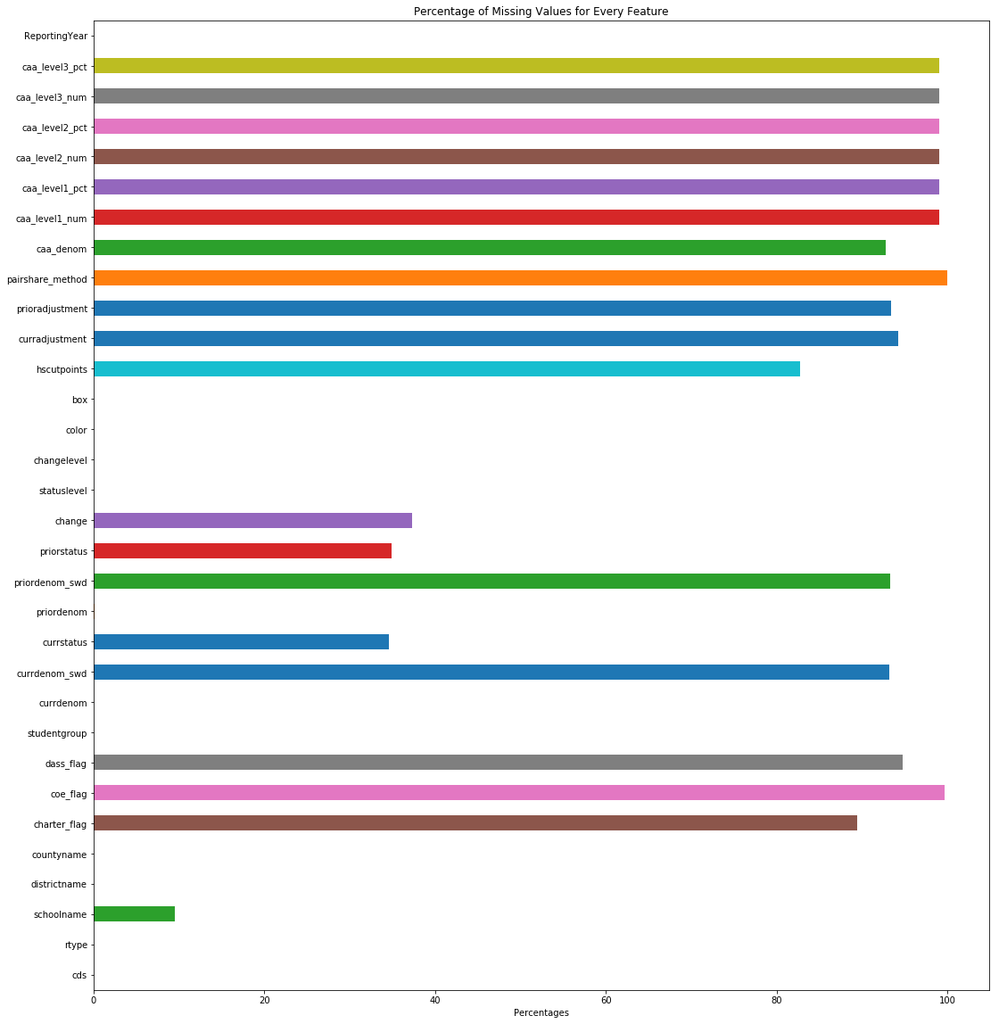

```python
#calcuate the missing percentage for each of the features
missing = math_df.isnull().sum()/len(math_df)*100

dx=missing.plot(kind='barh', figsize=(18,20))
plt.title('Percentage of Missing Values for Every Feature')
plt.xlabel('Percentages')
```

```
Text(0.5,0,'Percentages')
```

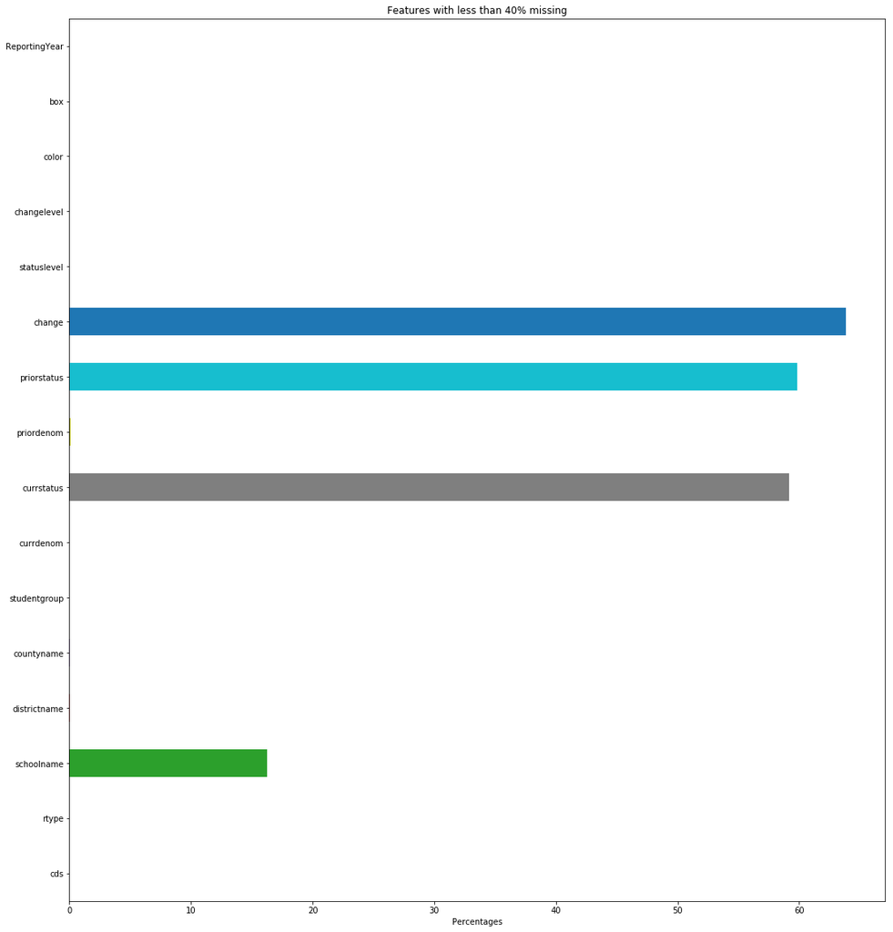

```python
# saving column names in a list called variable
variables = math_df.columns
variable = []

# setting threshold as 40% to impute features above the threshold
for i in range (0,32):
    if missing[i]<=40:
        variable.append(variables[i])

math2018_sub = math_df[variable]
missing_perc = math2018_sub.isnull().sum()/len(math2018)*100

ex=missing_perc.plot(kind='barh', figsize=(18,20))
plt.title('Features with less than 40% missing')
plt.xlabel('Percentages')
```

We also wanted to find the correlation of the features to better understand how it could impact the dependent variable of currstatus. From the correlation heatmap below, we found the following to be highly correlated (>60%):

- 'currdenom' and 'priordenom' (99%)
- 'priorstatus' and 'statuslevel' (81%)
- 'changelevel' and 'change' (86%)
- 'changelevel' and 'statuslevel' (66%)
- 'color' and 'box' (65%)

Moving forward, we will have to decided which features to select from each pair for further analysis.

```
Text(0.5,60,'Features')
```

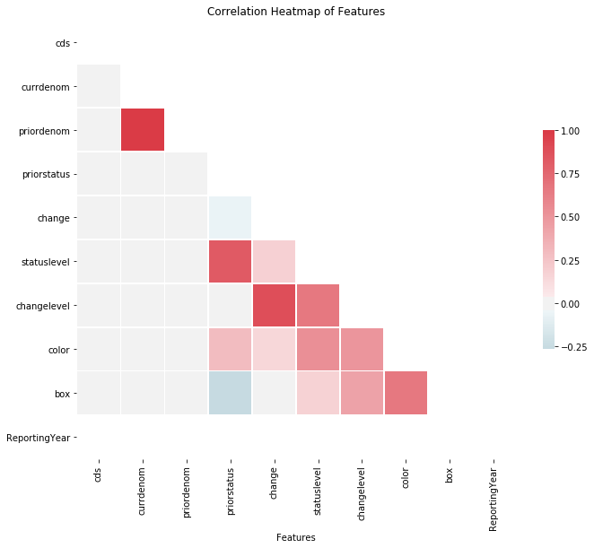

```python
# correlation calculation for the remaining features of interest. looking for correlations higher than 0.6.
# May need to remove one of the highly correlated features.  First remove the dependent variable: currstatus
import seaborn as sns
df = math2018_sub.drop('currstatus', 1)
corr = df.corr()

mask = np.zeros_like(corr, dtype=np.bool)
mask[np.triu_indices_from(mask)] = True

# Set up the matplotlib figure
f, ax = plt.subplots(figsize=(11, 9))

# Generate a custom diverging colormap
cmap = sns.diverging_palette(220, 10, as_cmap=True)

# Draw the heatmap with the mask and correct aspect ratio
sns.heatmap(corr, mask=mask, cmap=cmap, vmax=1, center=0,
            square=True, linewidths=.5, cbar_kws={"shrink": .5})
plt.title('Correlation Heatmap of Features')
plt.xlabel('Features')
```

We found that the best way, initially to visualize the data was to first look at the average distance from passing, as calculated through an aggregate function.

```python
#Group School Type and Student Group and report average distance from 'passing' for 2018

math2018_grouped= math2018.groupby(by=['SchoolType', 'studentgroup'])
math2018_AvgDistance = math2018_grouped.currstatus.sum() / math2018_grouped.currstatus.count()
math2018_AvgDistance
```

```
SchoolType  studentgroup
AltCharter  AA             -169.726087
            AI             -131.742857
            ALL            -162.358824
            AS              -88.800000
            EL             -185.802381
            ELO            -210.133333
            EO             -154.000000
            FI              -30.800000
            HI             -169.618056
            HOM            -189.800000
            MR             -117.754545
            RFP            -159.088000
            SED            -168.763750
            SWD            -201.433333
            WH             -131.386957
AltPublic   AA             -220.220000
            ALL            -199.196992
            AS              -37.725000
            EL             -222.866923
            ELO            -225.562500
            EO             -190.538745
            FI               37.100000
            HI             -206.182935
            HOM            -213.363158
            MR              -73.733333
            RFP            -207.442857
            SED            -205.226048
            SWD            -196.759091
            WH             -159.682540
Charter     AA              -76.660156
                               ...
            EL              -66.374906
            ELO            -103.180813
            EO              -36.011896
            FI               18.334906
            FOS            -178.900000
            HI              -51.828049
            HOM             -75.477083
            MR               -7.365854
```

[output cut: 8 more lines]

```
            AS               35.992458
            EL              -57.178947
            ELO             -97.511655
            EO              -30.015609
            FI               15.295572
            FOS            -123.250000
            HI              -50.756406
            HOM             -75.074270
            MR                8.097910
            PI              -69.436667
            RFP             -17.766481
            SED             -51.550202
            SWD            -113.291341
            WH               -9.582096
Name: currstatus, Length: 63, dtype: float64
```

```
Text(0.5,0,'Distance from Passing')
```

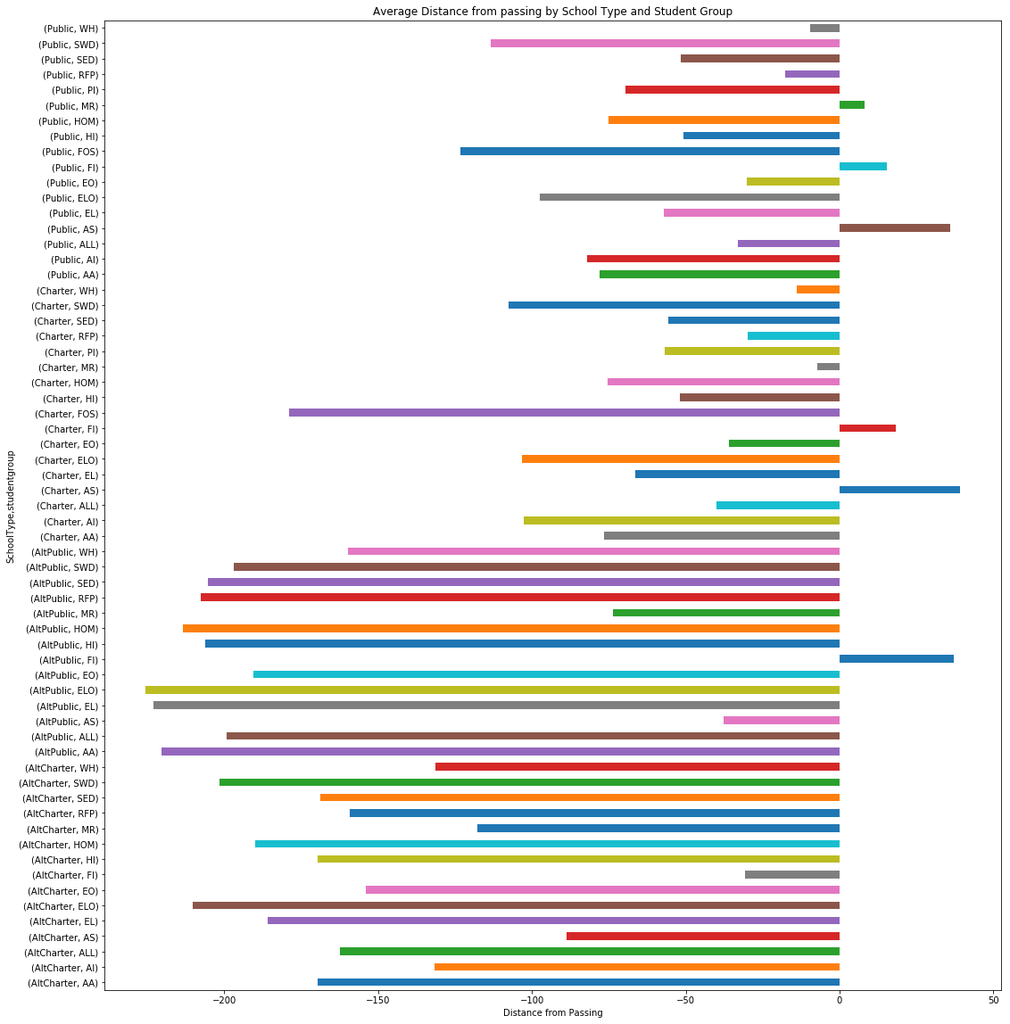

```python
ax=math2018_AvgDistance.plot(kind='barh', figsize=(18,20))
plt.title('Average Distance from passing by School Type and Student Group')
plt.xlabel('Distance from Passing')
```

In order to better visualize the information from the student groups column, we split the data into two different groupings. One grouping is all race/ethnicity categories. The other grouping is all of the various special programs that are measured. The "ALL" category was left out as it is simply the average of the averages all together. The data below represent the average distance from passing for each student group and school type. In both visual break-outs, it is apparent that the alternative campuses, both public and charter, perform worse on average than their non-alternative counterparts.

```python
#Create an Ethnicity/Race Subgroup to compare like data.

math2018ETH=(math2018[(math2018.studentgroup == 'AA') | (math2018.studentgroup == 'AI')| (math2018.studentgroup == 'AS')| (math2018.studentgroup == 'FI')| (math2018.studentgroup == 'HI')| (math2018.studentgroup == 'PI')| (math2018.studentgroup == 'WH')| (math2018.studentgroup == 'MR')])

#Create a smaller cross table with just the eth/race columns

math2018_AvgDistETH=pd.crosstab(math2018ETH.SchoolType, math2018ETH.studentgroup, values = math2018ETH.currstatus, aggfunc='mean').round(2)
math2018_AvgDistETH
```

| studentgroup SchoolType | AA | AI | AS | FI | HI | MR | PI | WH |
| --- | --- | --- | --- | --- | --- | --- | --- | --- |
| AltCharter | -169.73 | -131.74 | -88.80 | -30.80 | -169.62 | -117.75 | NaN | -131.39 |
| AltPublic | -220.22 | NaN | -37.72 | 37.10 | -206.18 | -73.73 | NaN | -159.68 |
| Charter | -76.66 | -102.71 | 39.17 | 18.33 | -51.83 | -7.37 | -56.95 | -14.02 |
| Public | -78.07 | -81.95 | 35.99 | 15.30 | -50.76 | 8.10 | -69.44 | -9.58 |

```
Text(0.5,0,'School Type')
```

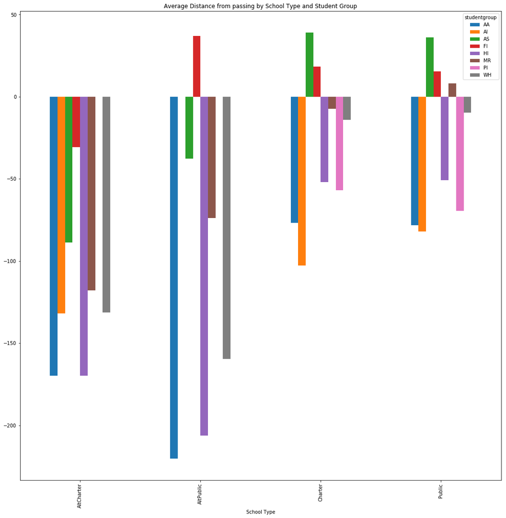

```python
#Use it to create bar chart to show smaller set of data (Eth/race)

math2018_AvgDistETH.plot(kind = 'bar', figsize=(18,18), stacked=False)
plt.title('Average Distance from passing by School Type and Student Group')
plt.xlabel('School Type')
```

```python
#Create an 'programs' Subgroup to compare like data.

math2018PROG=(math2018[(math2018.studentgroup == 'EL') | (math2018.studentgroup == 'ELO')| (math2018.studentgroup == 'RFP')| (math2018.studentgroup == 'EO')| (math2018.studentgroup == 'SED')| (math2018.studentgroup == 'SWD')| (math2018.studentgroup == 'FOS')| (math2018.studentgroup == 'HOM')])

#Create a smaller cross table with just the Programs columns

math2018_AvgDistPROG=pd.crosstab(math2018PROG.SchoolType, math2018PROG.studentgroup, values = math2018PROG.currstatus, aggfunc='mean').round(2)
math2018_AvgDistPROG
```

| studentgroup SchoolType | EL | ELO | EO | FOS | HOM | RFP | SED | SWD |
| --- | --- | --- | --- | --- | --- | --- | --- | --- |
| AltCharter | -185.80 | -210.13 | -154.00 | NaN | -189.80 | -159.09 | -168.76 | -201.43 |
| AltPublic | -222.87 | -225.56 | -190.54 | NaN | -213.36 | -207.44 | -205.23 | -196.76 |
| Charter | -66.37 | -103.18 | -36.01 | -178.90 | -75.48 | -29.98 | -55.79 | -107.66 |
| Public | -57.18 | -97.51 | -30.02 | -123.25 | -75.07 | -17.77 | -51.55 | -113.29 |

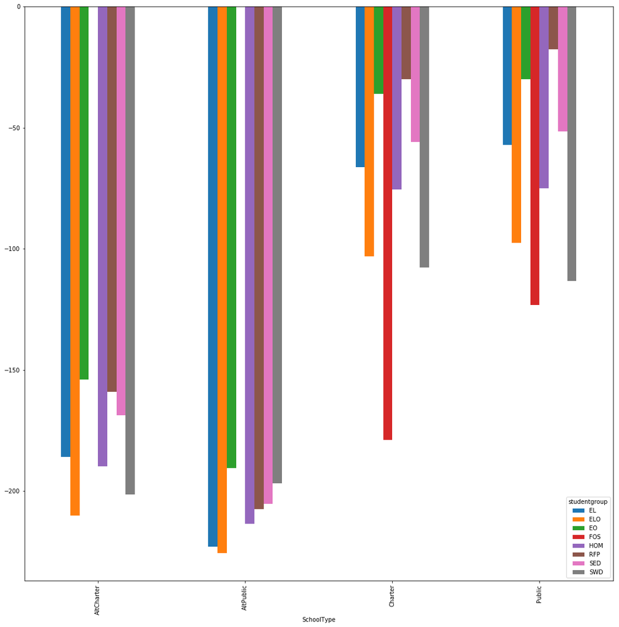

```python
#use it to create bar chart to show smaller set of data (programs)

math2018_AvgDistPROG.plot(kind = 'bar', figsize=(18,18), stacked=False)
```

## Explore Attributes and Class

From the above two tables it is clear that Alternative schools, whether in the public or charter settings perform worse than their "regular" counterpart. With the exception of the Filipino student group that seems to excel in the public alternative school setting, performing bettern then their counterparts in charter and public schools. Alternatively, the foster children in the school systems requires attention. They are the worse performing group within the public shool system. Although we do not have enough data on foster children within the alternative school systems to compare it is still worth noting that the foster children within the charter school system performs comparably with the general populations of the alternative school systems surpassing their peers.

## New Features

As mentioned above, the data is presented in such a way that made comparing different school types difficult. There are various columns with a 'Y' or blank entry, each based on the data being from either a Charter School, County Entity, or an Alternative School (3 separate columns). Additionally, there is another column that tells us if the data is from either state, district/LEA, or school (1 column). In order to get one label for each line of data based on this data, a new feature was created called SchoolType. The New feature created was, "SchoolType". Based on the 4 columns mentioned above, SchoolType attributes are Public, Charter, AltPublic, AltCharter, District, County, and State. This was described earlier in the document in order to use these features in the analysis. (see code from Explore Attributes Section)

## Exceptional Work

Using the number of students that sat the math exam, currdenom, from all the school as the input variable and the distance from passing for each school, currstatus of the 'ALL' group. We attempt to ascertain the 5 most important student groups responsible for the status of the school. Since there is only one response variable a univariate approach to feature selection. The continous nature of the response variable lend itself for us to use the f_regression scoring function.

```python
from IPython.display import clear_output

currstatus2018 = math2018[["cds", "studentgroup", "currstatus", "currdenom"]] #parse out data for manipulation
index = math2018.cds.unique() #extract all unique cds codes
studentgroups = currstatus2018.studentgroup.unique().tolist() #extract all unique student groups
studentgroups = studentgroups + ["currstatus"]
newtable = pd.DataFrame(index = index, columns=studentgroups)
#reorient table, saved to a csv file because code is computationally intensive
#print(newtable.shape)
#count=0
#for i in newtable.index:
#    for s in studentgroups:
#        count = count+1
#        if (s != "currstatus"):
#            temp = currstatus2018.currdenom[(currstatus2018.studentgroup == s) & (currstatus2018.cds == i)].values
#            if temp.size:
#                newtable[s][i] = int(temp)
#        else:
#            temp = currstatus2018.currstatus[(currstatus2018.studentgroup == "ALL") & (currstatus2018.cds == i)].values
#            if temp.size:
#                newtable[s][i] = float(temp)
#        print(count)
#        clear_output()
#newtable = newtable.drop(columns=['ALL'])
#newtable.to_csv("newtable.csv", sep=',', index=True)
newtable = pd.read_csv("newtable.csv", index_col=0)
```

```python
#perform univariate feature selection
from sklearn.feature_selection import SelectKBest
from sklearn.feature_selection import f_regression

def featureselection(table):
    array = table.values #change pandas dataframe to numpy array
    array[np.isnan(array)] = 0 #impute all NaN to 0
    _input = array[:,0:16] #parse out features to be filtered
    _target = array[:,16] #parse out response variable

    #feature selecton using SelectKBest with f_regression as scoring function
    test = SelectKBest(score_func=f_regression, k=4)
    fit = test.fit(_input, _target)
    features = fit.transform(_input)

    #match scores to feature names and display
    index=list(table)[:-1]
    np.set_printoptions(precision=3)
    values=fit.scores_
    featurescores = pd.DataFrame(values, index=index, columns=["scores"])
    featurescores.sort_values(by=['scores'], inplace=True, ascending=False)
    print(featurescores[:5])

featureselection(newtable)
```

```
          scores
AS   1651.882675
MR   1443.252726
WH   1433.300014
EO   1041.053700
SED   283.016537
```

```
array([[<matplotlib.axes._subplots.AxesSubplot object at 0x1a318675c0>,
      dtype=object)
```

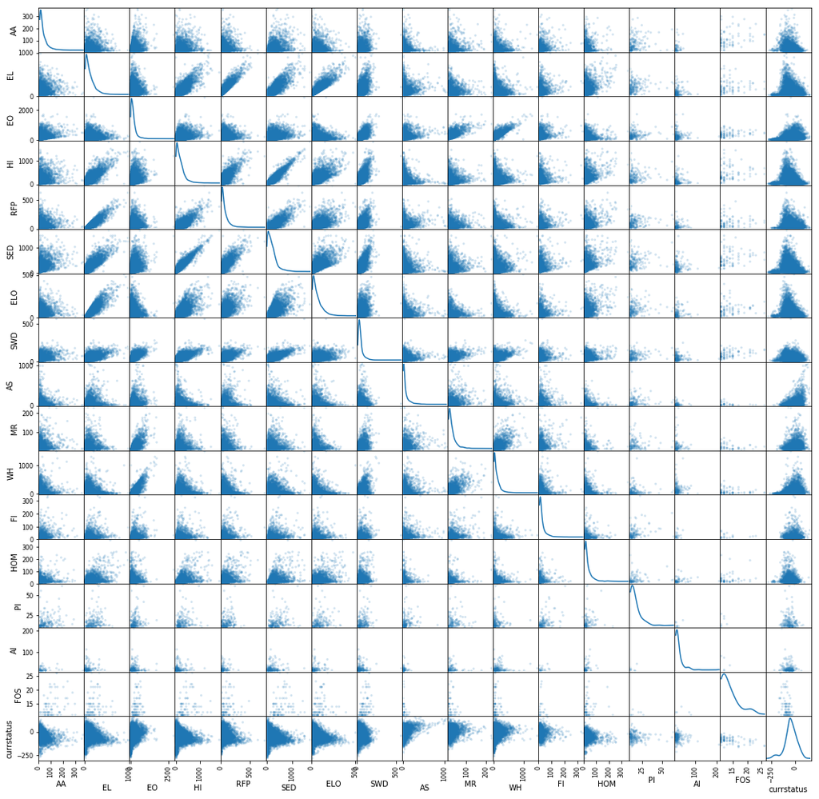

```python
from pandas.plotting import scatter_matrix

newtable = pd.read_csv("newtable.csv", index_col=0)
scatter_matrix(newtable, alpha = 0.2, figsize = (18, 18), diagonal = 'kde')
```

```
array([[<matplotlib.axes._subplots.AxesSubplot object at 0x122f41ac8>,
      dtype=object)
```

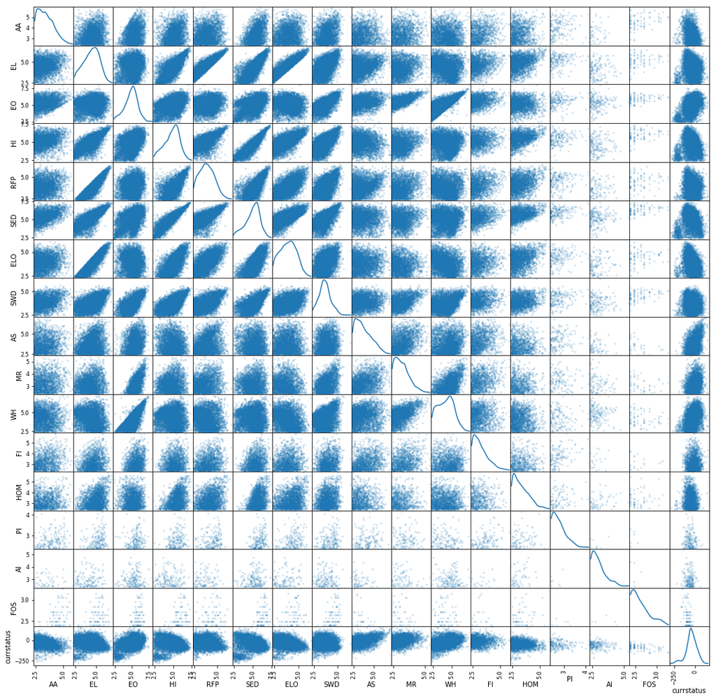

```python
newtable = pd.read_csv("newtable.csv", index_col=0)
temp = newtable.drop(columns=['currstatus'])
logtable = temp.applymap(lambda x: np.log(x))
logtable = logtable.join(newtable.currstatus)
scatter_matrix(logtable, alpha = 0.2, figsize = (18, 18), diagonal = 'kde')
```

```python
featureselection(logtable)
```

```
          scores
EO   2887.668566
WH   2699.556589
AS   2593.867734
MR   2142.160284
SWD   805.428908
```